# (Bay Wheels System Data Analzing)

## by (Nourh Almutairi)

## Preliminary Wrangling

> Bay Wheels is a regional public bicycle sharing system in California's San Francisco Bay Area.Bay Wheels is the first regional and large-scale bicycle sharing system deployed in California and on the West Coast of the United States. The system is expected to expand to 7,000 bicycles around 540 stations in San Francisco, Oakland, Berkeley, Emeryville, and San Jose. in this project i focus on the first three months of 2020.(January,February, March) and trying to find answrs for some questions.

### What is the structure of your dataset?

- Trip Duration (seconds)
- Start Time and Date
- End Time and Date
- Start Station ID
- Start Station Name
- Start Station Latitude
- Start Station Longitude
- End Station ID
- End Station Name
- End Station Latitude
- End Station Longitude
- Bike ID
- User Type (Subscriber or Customer – “Subscriber” = Member or “Customer” = Casual)

### What is/are the main feature(s) of interest in your dataset?

> Trip Duration , User Type , Start Station Name,End Station Name

### What features in the dataset do you think will help support your investigation into your feature(s) of interest?

> Bike ID , Start Time and Date , End Time and Date

## Univariate Exploration

### User Type

#### who is the most used of ford GoBike system (Subscriber vs Customers)

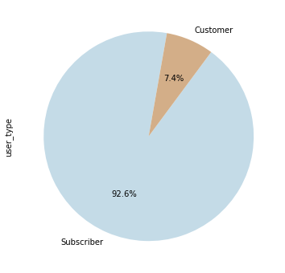

```python
plt.figure(figsize=(10,6))
BWdata_clean.user_type.value_counts().plot(kind='pie',autopct='%1.1f%%',startangle=80 , colors = ['#c4dbe7', '#d3ae88'])
```

### Rental Access Method

#### what is the most used method (App vs Clipper)

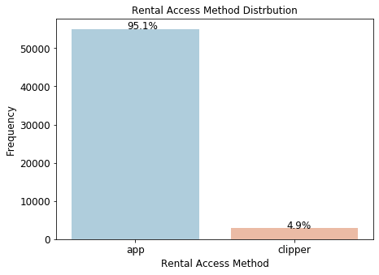

```python
plt.figure(figsize=(7,5))
ax=sb.countplot('rental_access_method',data=BWdata_clean,palette = "RdBu_r")
plt.xticks(size=12)
plt.xlabel('Rental Access Method', size = 12)
plt.yticks(size=12)
plt.ylabel('Frequency', size = 12)
plt.title('Rental Access Method Distrbution')
without_hue( ax ,BWdata_clean.rental_access_method)
```

### Start station and End Station name

#### What is the Top 5 in each

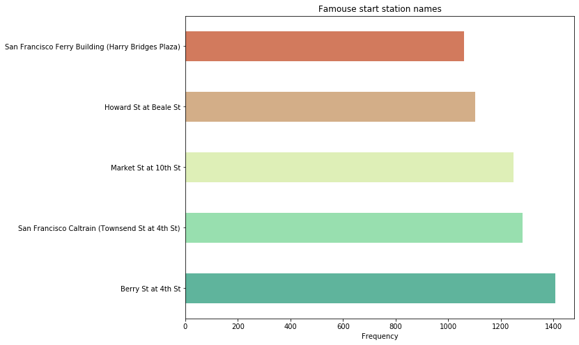

```python
BWdata_clean.start_station_name.value_counts()[0:5].plot(kind='barh', figsize=(10,8), title='Famouse start station names',color=['#5fb49c', '#98dfaf', '#deefb7', '#d3ae88', '#d27a5d']).set_xlabel("Frequency")
```

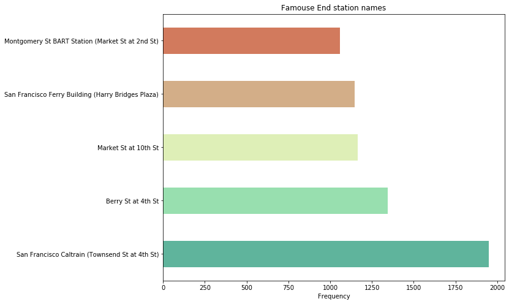

```python
BWdata_clean.end_station_name.value_counts()[0:5].plot(kind='barh', figsize=(10,8), title='Famouse End station names',color=['#5fb49c', '#98dfaf', '#deefb7', '#d3ae88', '#d27a5d']).set_xlabel("Frequency")
```

### Duration Time Distrbution

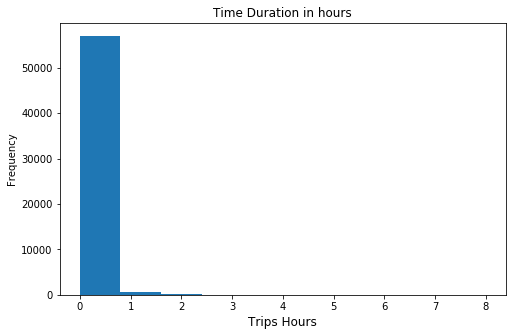

```python
plt.figure(figsize=(8,5))

BWdata_clean['duration_time'].astype('timedelta64[h]').plot.hist(title = 'Time Duration in hours')
plt.xlabel('Trips Hours', size = 12)
```

### Which day user being more active

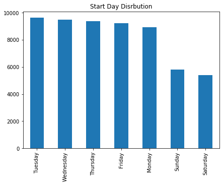

```python
plt.figure(figsize=(7,5))
BWdata_clean['start_day'].value_counts().plot(kind='bar')
plt.title('Start Day Disrbution')
```

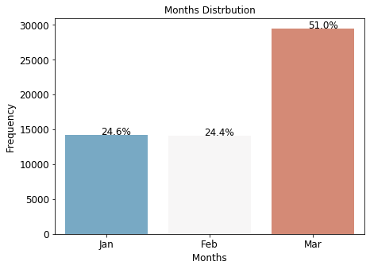

```python
plt.figure(figsize=(7,5))
ax=sb.countplot('month',data=BWdata_clean,palette = "RdBu_r")
plt.xticks(size=12)
plt.xlabel(' Months ', size = 12)
plt.title('Months Distrbution')
plt.yticks(size=12)
plt.ylabel('Frequency', size = 12)
without_hue( ax ,BWdata_clean.month)
```

### Which time users usualy start bikes trips

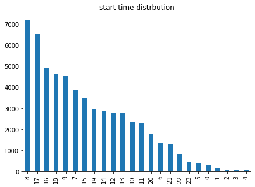

```python
plt.figure(figsize=(7,5))
BWdata_clean['start_time_hour'].value_counts().plot(kind='bar')
plt.title('start time distrbution')
```

## Bivariate Exploration

### Relationship between trip duration and week day .

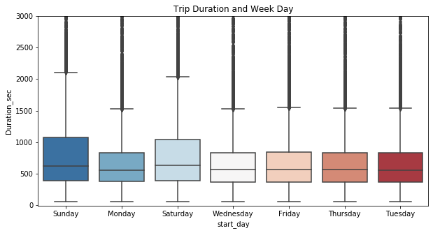

```python
plt.figure(figsize = [10, 5])
sb.boxplot(data = BWdata_clean, x = 'start_day', y = 'duration_sec', palette = "RdBu_r")
plt.ylim([-10, 3000])
plt.title('Trip Duration and Week Day')
plt.ylabel('Duration_sec')
plt.show()
```

### Relashionship between user type and trip duration

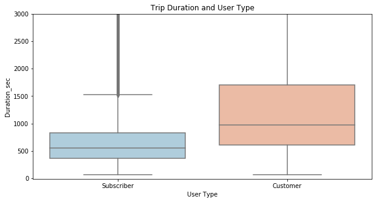

```python
plt.figure(figsize = [10, 5])
sb.boxplot(data = BWdata_clean, x = 'user_type', y = 'duration_sec', palette = "RdBu_r")
plt.ylim([-10, 3000])
plt.title('Trip Duration and User Type')
plt.xlabel('User Type')
plt.ylabel('Duration_sec')
plt.show()
```

### week day and month distrbution

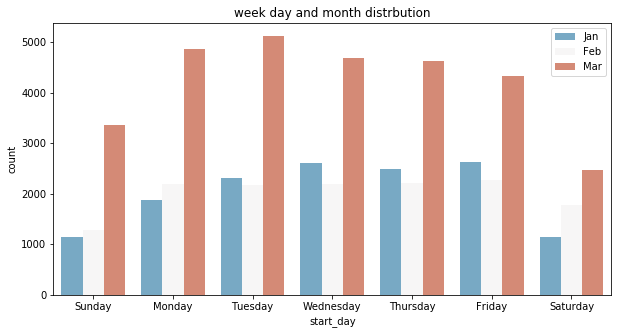

```python
plt.figure(figsize = [10, 5])
cat1_order = ['Sunday', 'Monday', 'Tuesday', 'Wednesday','Thursday','Friday','Saturday']
cat2_order = ['Jan', 'Feb', 'Mar']
sb.countplot(data = BWdata_clean, x = 'start_day', hue = 'month',order = cat1_order, hue_order = cat2_order,palette = "RdBu_r")
plt.legend()
plt.title('week day and month distrbution')
```

### Relashionship between start time and week day

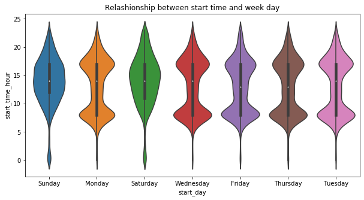

```python
plt.figure(figsize = [10, 5])
sb.violinplot(data = BWdata_clean, x = 'start_day', y = 'start_time_hour')
plt.title('Relashionship between start time and week day')
```

### Relashionship between start time and duration time

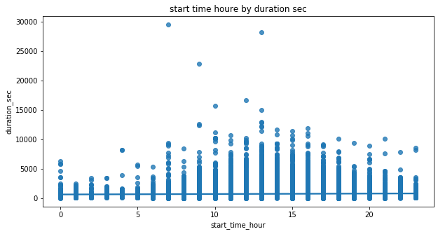

```python
plt.figure(figsize = [10, 5])
sb.regplot(x='start_time_hour',y='duration_sec',data=BWdata_clean, fit_reg=True)
plt.title('start time houre by duration sec')
```

## Multivariate Exploration

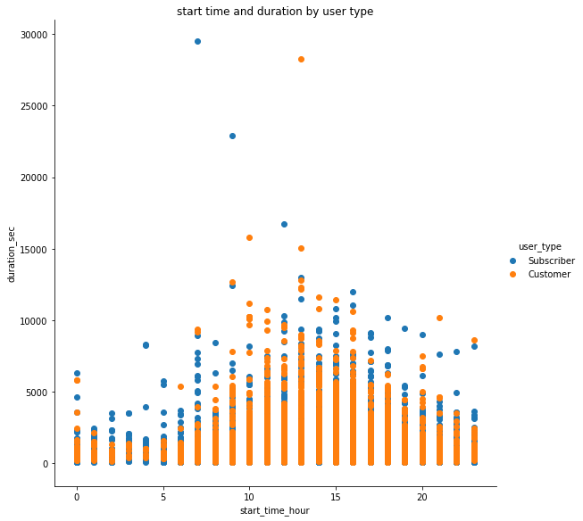

```python
plt.figure(figsize = [10, 5])
g = sb.FacetGrid(data = BWdata_clean, hue = 'user_type', height = 8)
g.map(plt.scatter, 'start_time_hour', 'duration_sec')
g.add_legend()
plt.title('start time and duration by user type')
```

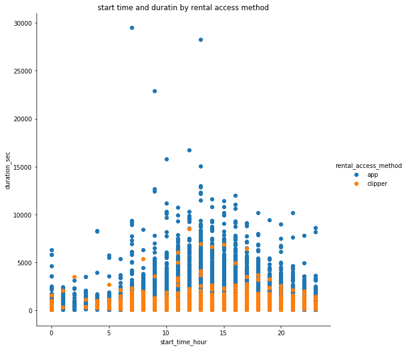

```python
plt.figure(figsize = [10, 5])
g = sb.FacetGrid(data = BWdata_clean, hue = 'rental_access_method', height = 8)
g.map(plt.scatter, 'start_time_hour', 'duration_sec')
g.add_legend()
plt.title('start time and duratin by rental access method');
```